# Transcriptional response to polyethylene glycol-coated graphene oxide-erlotinib in nasopharyngeal carcinoma cell line

Caden McQuillen

2023-04-17

## Introduction

Nasopharyngeal carcinoma (NPC) is a cancer affecting the upper part of the pharynx behind the throat and usually originates in squamous cells that line the nasopharynx. It is a very rare cancer in western countries but is an endemic in southern China, southeast Asia and north Africa (Wong et. al., 2021). Additional risk factors such as exposure to Epstein-Barr virus and environmental carcinogens can greatly increase risk of incidence (Wong et. al., 2021). In its early stage, NPC is highly curable and very responsive to radiotherapy (Lan et. al., 2020). However due to initially vague symptoms and secluded location within the nasal cavity, many cases go undiagnosed until their later stages, when NPC becomes less radiosensitive and harsher more toxic treatments like chemotherapy are also required (Lan et. al., 2020). While the development of better diagnostic tools is paramount to increasing early detection and thus improving patient outcome, a crucial orthogonal aim is the advent of safe and effective therapies for late stage NPC.

Advancements in bio-engineering nanoparticles such as Graphene have allowed for targeted drug delivery due to their large surface-to-volume ratio, hydrophobicity, and amenity for near-infrared (NIR) photoresponsiveness (Wang et. al., 2020). Graphene also has the advantage of being pH-dependent meaning it will increase the release rate of the drug with decreased pH levels. This is especially useful for uniquely targeting cancer cells, since many tumor cells have high metabolic activity and consequently have more acidic intracellular pH. Therefore, Graphene based drug carriers can used to specifically target tumor cells.

Erlotinib is a tyrosine kinase inhibitor which acts on the epidermal growth factor receptor (EGFR). It has shown to be effective for treating locally advanced or metastatic non-small cell lung cancer (NSCLC) and pancreatic cancer, however its use in NPC is still currently unknown. Previous work has identified critical NPC molecular targets many of which are amenable to treatment with erlotinib (Lan et. al., 2020). However, drug delivery and the unique targeting of the cancer cells remains a challenge due to location of NPC. Therefore, erlotinib delivered via polyethylene glycol-coated graphene oxide (GO-PEG) may an effective treatment for late stage NPC. In this analysis, I aim to uncover the efficacy of GO-PEG-erlotinib in suppressing key NPC pathways *in vitro* using a reproducible bulk RNA-seq pipeline.

## Results

### BGISEQ fastq files have identical phred scores

The current gold standard for next generation short read sequencing is Illumina-based sequencers and many of the tools for downstream processing are optimized for Illumina data, thus when analyzing data from less frequently used sequencers like Beijing Genomics Institute (BGISEQ) further considerations need to be made. One particular example are the phred score in the fastq files generated by BGISEQ-500 (which uses phred+33 encoding) where the phred score for every base has an identical score of 30 or “?” (**Figure 1**). I could not find any evidence suggesting this is intended output generated by the standard BGISEQ protocol however, so I am not sure if this phenomena is unique to this data set or a consequence of BGISEQ data in general. Besides being unexpected result and limiting the usable information in the fastq files for quality control, I did not notice any adverse effects in downstream analysis.

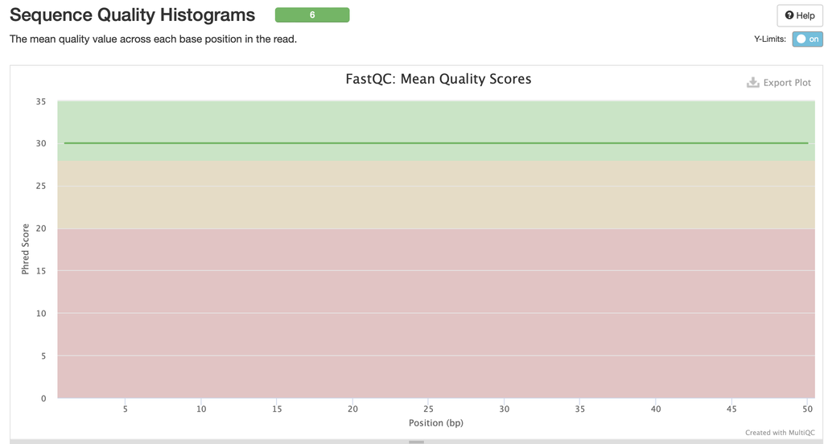

**Figure 1**

### Control 4 is an outlier sample

The quality of the biological replicates is crucial to robust and reproducible results in RNA-seq analysis. In the original study, the authors make no mention of any quality control steps performed or any removal of potential outliers. However when processing the same data myself I found one control replicate that deviates significantly from both the other control replicates and GPE treated replicates in PCA space (**Figure 2**). We can see that PC1 accounts for 64.15% of the variance, however most of the variation seems to be due to Control 4. While the other samples seem to be contained on the range [-10, 2] of PC1 and [-10,10] on PC2, Control 4 has a PC1 coordinate of >20. Within the range of the non-Control 4 samples, the experimental conditions seem to separate nicely by condition along both PC1 and PC2.

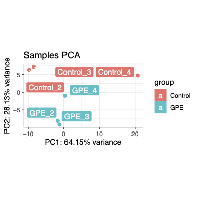

**Figure 2**

We can also observe this effect at the differential gene analysis level, with the p value distribution changing significantly with the removal of Control 4 (**Figure 3**). With the Control 4 sample included we get a distribution that skews towards the non-significant end and is reminiscent of a random distribution with little signal. When removing the Control 4 sample we get a distribution that skews towards the significant end and is more reminiscent of the biological signal we would expect to see in a drug treated experiment. Therefore I chose to remove the Control 4 sample for downstream analysis.

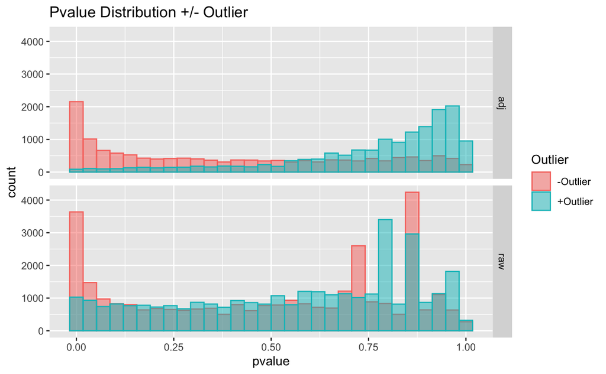

**Figure 3**

### GO-PEG-Erlotinib downregulates cancer-related phenotype in vitro

After removing Control 4, differential gene analysis between GPE-treated and control NPC cells was performed using DEseq2. Hierarchical clustering of the differential expressed genes (DEGs) shows that GPE-treatment results in a distinct transcriptional response in NPC cells (**Figure 4**). When examining the top individual DEGs we can see that there is some consistency between my results and the original study, in particular *CHAC1* is the top up-regulated gene and *KRCC1* is a top 3 up-regulated gene by adjusted p-value in both analyses. *ART1*, *SLC17A7*, and *NPTX1* were all top 10 down-regulated DEGs in both analyses as well, suggesting that some effects are robust across methods (**Figure 5**). These top up-regulated genes have known anti-tumor function, in particular *CHAC1* has been shown to induce apoptosis and decrease cell proliferation in head and neck squamous cell cancer cell lines (Lan et. al., 2020). Conversely, *NPTX1* a top down-regulated gene in both analyses, has recently been associated with the progression of lung, pancreatic, and colon cancers (Lan et. al., 2020). However there is also considerable variability in the results of both analyses with many of the top 10 DEGs from their study not appearing in the top 25 of my analysis. Furthermore the total number of DEGs varied immensely between analyses with their total being 1455 DEGs with adjusted p value $< 0.05$ and | log2 Fold Change | $>= 2$ and mine being 205 without Control 4 and 62 with Control 4. This inconsistency between results was further exacerbated by the limited description of computational methods used and lack of code availability in the original study.

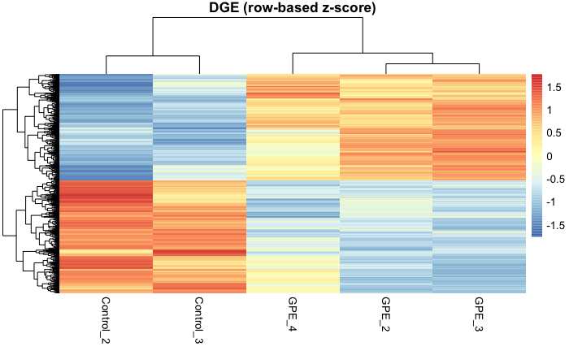

**Figure 4**

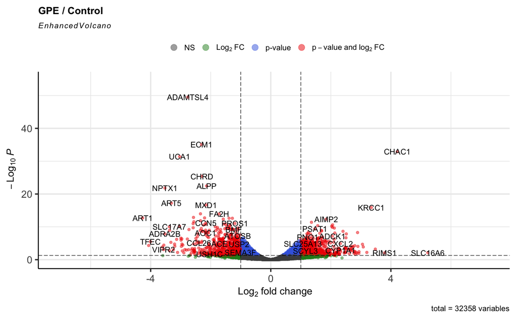

**Figure 5**

To better characterize the cumulative biological effects of GPE treatment, I performed pathway enrichment analysis on the DEGs generated previously. We can see that with treatment of GPE, there is significant down regulation of cancer related pathways such as *Proteoglycans in cancer*, *Pathways in cancer*, and *Small cell lung cancer* which may suggest GPE effectively suppresses crucial NPC functions (**Figure 6**). Furthermore, we can see down regulation of *MAPK signaling pathway* , *PI3K-Akt signaling pathway*, and *Ras signaling pathway* which are all pro-tumorigenic pathways that are downstream of the EGFR signaling pathway, the molecular target of erlotinib (Oda et. all, 2005). However these results should be interpreted with caution as we again see inconsistency between my results and the original study despite using the same pathway database (KEGG). This lack of consistency makes sense considering the enrichment of these pathways is based on the statistical overlap of the differential expressed genes with the curated gene sets in the database and therefore would mirror the inconsistency of the DEG analysis. However, this should give less confidence to results that are not consistent between both analyses.

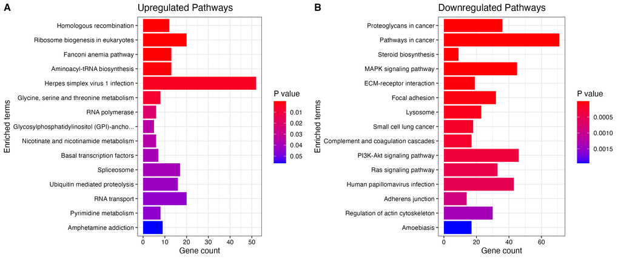

**Figure 6**

### Limitations and future directions

The major limitation of this data set is the small number of replicates, while the recommend number of replicates is n >= 6 per condition this data only had n = 3 for GPE and n = 2 for Control after removal of outliers. Since there are many technical biases that can arise during RNA-seq library preparation, an under powered data set may not be accurately sampling the true transcriptome. This was highlighted by considerable variation between Control 4 and the other control replicates which should be fairly consistent given this is cell line data. The other obvious limitation of this data is in its potential translational impact given that this experiment was performed *in vitro*. It is unclear if the drug delivery system will be equally effective in an *in vivo* setting and effective drug delivery is one of the major challenges of NPC treatments. Even if the molecular pathways targeted by GPE are correct, the delivery efficacy *in vivo* is still undetermined. Lastly, since this is bulk RNA-seq data we do not know which cells specifically up took the drug or what percentage of the cells up took the drug. Earlier in the original study they florescent labeled GO-PEG to confirm intra-cellular uptake, but they don’t mention adding florescence to GO-PEG-Erlotinib and they don’t mention selecting cells by florescence when doing the RNA sequencing. Therefore we can’t with 100% certainty directly link the transcriptional effects to the drug although it is likely the cause.

Due to the potentially under powered results I would suggest the first follow up experiment would be to perform the *in vitro* study again but with greater number of replicates. I believe that while some of the results from this data set are promising, it needs to be reproduced in an identical experiment with larger sample size. If similar results are achieved then follow up *in vivo* studies which test the drug delivery efficacy would be needed, with the ultimate goal of clinical trials.

## Methods

### Data Download

Fastq files were downloaded from SRA: SRP264795, GEO: GSM4568395. #### Download Fastq files

```bash
while read ID; do
 wget "https://trace.ncbi.nlm.nih.gov/Traces/sra-reads-be/fastq?acc=${ID}" -O ${ID}.fastq.gz
done < SRR_ACC_List.txt
```

### Fastq Quality Control

Fastqc was run on each individual sample’s fastq file and then aggregated using multiqc. Per base phred scores were identical (30) for every base in every read across all samples. Per base sequence content “failed” for 5/6 samples and “warned” 1/6 samples however the bases in question were all within the first 12 bps of the reads. I believe this may be caused by library preparation, in particular biased fragmented possibly due to using transposases which can bias the start of reads. I don’t believe it should adversely affect the downstream analysis. Additionally, sequence duplication also failed in 5/6 samples specifically at sequences centered around “>10 bps”. I believe this is picking up the same issue as the per base sequence content and could possibly be a product of BGISEQ library prep.

#### fastqc and multiqc

```bash
for file in *; do
  fastqc $file --extract;
done
#On interactive session
srun -n1 --pty --partition=angsd_class --mem=4G bash -i
cd /athena/angsd/scratch/cnm4001/NPC_fastq_data
mamba activate multiqc
multiqc .
```

### Indexing Human Genome

I downloaded the GRCh38 genome from UCSC via this url: ftp://hgdownload.cse.ucsc.edu/goldenPath/hg38/bigZips/latest/hg38.fa.gz I then downloaded the gencode V41 GTF from UCSC table browser however I later discovered that this file lacks transcript and gene entries and only has CDS, exon, start_codon, and stop_codon. For later analysis such as feature counts I downloaded a new GTF file but I had already used this file indexing with STAR. To index the genome, I used STAR generate genome with the above fasta and “GTF” files respectively. I also used sjdbOverhang = 49 = read length - 1 and otherwise all other default parameters. The sjdbOverhang parameter tells STAR how many bases to concatenate from donor and acceptor sides of the junctions, we want the maximum possible overhang for our reads therefore I set this parameter as readlength - 1 = 49. I’m not sure if this incorrect GTF file had any adverse affects in downstream analysis, the results I generated made sense to me but still differed from the original paper in some ways so this GTF file could possibly be a reason why.

#### Download human genome

```bash
#On local copy over gtf file
scp /Users/Caden/Downloads/hg38.gencodev41.gtf cnm4001@aphrodite.med.cornell.edu:/athena/angsd/scratch/cnm4001/hg38
#Download Genome to cluster
wget 'ftp://hgdownload.cse.ucsc.edu/goldenPath/hg38/bigZips/latest/hg38.fa.gz' -O hg38.fa.gz
#STAR needs unzipped genome file
gunzip hg38.fa.gz
```

#### Index hg38 genome

```bash
STAR --runMode genomeGenerate \
  --runThreadN 1 \
  --genomeDir hg38_STARindex \
  --genomeFastaFiles /athena/angsd/scratch/cnm4001/hg38/hg38.fa \
  --sjdbGTFfile /athena/angsd/scratch/cnm4001/hg38/hg38.gencodev41.gtf \
  --sjdbOverhang 49
```

#### Download new gtf

```bash
#Download new GTF
wget 'https://ftp.ebi.ac.uk/pub/databases/gencode/Gencode_human/release_43/gencode.v43.annotation.gtf.gz' -O hg38.gencodev43.gtf.gz
```

### Alignment

To align the reads, I used STAR alignReads on each fastq file individually using the above indexed genome with outSAMtype = BAM SortedByCoordinate and all other default parameters. I then used Samtools index to generate indexed BAM files for each of the individual sample’s BAM files. MultiQC was used to aggregate STAR alignment scores for each of the samples. About 24 million reads mapped to unique loci in every sample by far made up the majority of reads in each sample. Based on this distribution I thought that my alignment looked good since most reads had mapped unique loci which meant more reads would be “usable” in downstream analysis. From this alone I still did not know where the reads were actually mapping to. To address this I visualized my BAM files in IGV using the same GRCh38 genome and updated gencode V43 GTF. From this I was able to see where my reads were aligning to. I also discovered that there were reads mapping to intronic regions and also uncharacteristic long coding RNAs in intergenic regions which made my think that my data was ribo depleted. Lastly, since I had reads going in both directions I confirmed that my data was unstranded.

#### Align fastq with STAR

```bash
for index in 597 598 599 600 601 602; do
  STAR --runMode alignReads \
    --runThreadN 1 \
    --genomeDir  hg38/hg38_STARindex \
    --readFilesIn  NPC_fastq_data/SRR11849${index}.fastq.gz\
    --readFilesCommand zcat \
    --outFileNamePrefix NPC_bams/SRR11849${index}. \
    --outSAMtype BAM SortedByCoordinate ;

  samtools index /athena/angsd/scratch/cnm4001/NPC_bams/SRR11849${index}.Aligned.sortedByCoord.out.bam
done
```

#### Multiqc on STAR output

```bash
srun -n1 --pty --partition=angsd_class --mem=4G bash -i
cd /athena/angsd/scratch/cnm4001/NPC_bams
mamba activate multiqc
multiqc .
```

### Alignment QC

I used QoRTs to perform alignment QC on each of the individual BAM files with flags -Xmx18000M QC, generatePlots, and singleEnded. The -Xmx18000M was recommended in the QoRTs documentation if you were experience java related memory issues as was the case with my data. The generatePlots flag automatically will generate all the R plots for you. Lastly, the singleEnded flag was added since my data is not paired end. For the GTF, I used the gencode V41 file I had used previously and multiQC was used to aggregate QoRTs output for all samples. Due to the incorrect file being used as the GTF, I was getting the vast majority of my reads mapping to “ambig gene” and only about 4-6 million reads mapping to unique genes in every sample. I then changed to a correct GTF file downloaded from: ‘https://ftp.ebi.ac.uk/pub/databases/gencode/Gencode_human/release_43/gencode.v43.annotation.gtf.gz’. I reran Qorts using the exact same parameters but using this GTF instead and got 22 million reads mapping to unique genes in every sample.

#### Alignment QC (bad GTF)

```bash
for index in 597 598 599 600 601 602; do
  qorts -Xmx18000M QC \
  --generatePlots \
  --singleEnded \
   SRR11849${index}.Aligned.sortedByCoord.out.bam \
  /athena/angsd/scratch/cnm4001/hg38/hg38.gencodev41.gtf  \
  /athena/angsd/scratch/cnm4001/NPC_alignmentQC/SRR11849${index}_alignmentQC
done

#multiqc
srun -n1 --pty --partition=angsd_class --mem=4G bash -i
cd /athena/angsd/scratch/cnm4001/NPC_alignmentQC
mamba activate multiqc
multiqc .
```

#### Rerun Qorts with new gtf

```bash
for index in 597 598 599 600 601 602; do
  qorts -Xmx18000M QC \
  --generatePlots \
  --singleEnded \
   SRR11849${index}.Aligned.sortedByCoord.out.bam \
  /athena/angsd/scratch/cnm4001/hg38/hg38.gencodev43.gtf  \
  /athena/angsd/scratch/cnm4001/NPC_alignmentQC/reRun_SRR11849${index}_alignmentQC
done
```

### Feature Counts

I initially ran featureCounts with the -O -fraction flags and all other default parameters to try and address the reads that mapped to ambigous genes which I thought meant the read overlapped with more than 1 annotated feature. I also used the incorrect genecode V41 GTF file from before. In the summary file, I had around 23000000+ assigned reads and 0 ambigous reads per sample which makes sense considering I fractionally counted any read that overlaped with more than 1 feature. Despite these potential misteps, the correlation of gene expression between replicates was still good and the conditions seemed to separate in PCA space (with the exception of Control 4).

After identifying that it was indeed the GTF file that was causing the issue, I reran featureCounts again using the updated correct gencode V43 GTF and all other default parameters. The summary file showed about 22 million assigned reads and only a little less than 2 million Unassigned_Ambiguity reads per sample.

#### Feature Counts (Bad GTF, -O flag)

```bash
featureCounts -O -fraction \
-a /athena/angsd/scratch/cnm4001/hg38/hg38.gencodev41.gtf \
-o /athena/angsd/scratch/cnm4001/NPC_counts/NPC_combined_featureCounts.txt \
/athena/angsd/scratch/cnm4001/NPC_bams/SRR11849597.Aligned.sortedByCoord.out.bam /athena/angsd/scratch/cnm4001/NPC_bams/SRR11849598.Aligned.sortedByCoord.out.bam
/athena/angsd/scratch/cnm4001/NPC_bams/SRR11849599.Aligned.sortedByCoord.out.bam
/athena/angsd/scratch/cnm4001/NPC_bams/SRR11849600.Aligned.sortedByCoord.out.bam
/athena/angsd/scratch/cnm4001/NPC_bams/SRR11849601.Aligned.sortedByCoord.out.bam
/athena/angsd/scratch/cnm4001/NPC_bams/SRR11849602.Aligned.sortedByCoord.out.bam
```

#### Rerunning Feature Counts without -O flag

```bash
featureCounts -a /athena/angsd/scratch/cnm4001/hg38/hg38.gencodev41.gtf \
-o /athena/angsd/scratch/cnm4001/NPC_counts/NPC_combined_featureCounts.txt \
/athena/angsd/scratch/cnm4001/NPC_bams/SRR11849597.Aligned.sortedByCoord.out.bam /athena/angsd/scratch/cnm4001/NPC_bams/SRR11849598.Aligned.sortedByCoord.out.bam
/athena/angsd/scratch/cnm4001/NPC_bams/SRR11849599.Aligned.sortedByCoord.out.bam
/athena/angsd/scratch/cnm4001/NPC_bams/SRR11849600.Aligned.sortedByCoord.out.bam
/athena/angsd/scratch/cnm4001/NPC_bams/SRR11849601.Aligned.sortedByCoord.out.bam
/athena/angsd/scratch/cnm4001/NPC_bams/SRR11849602.Aligned.sortedByCoord.out.bam
```

#### Compare featureCounts results +/- -O flag

```r
old_counts_summary <- read.table("/Users/Caden/Desktop/angsd/project/angsd_project/FeatureCounts/old_counts/NPC_combined_featureCounts.txt.summary", header = TRUE)

new_counts_summary <- read.table("/Users/Caden/Desktop/angsd/project/angsd_project/FeatureCounts/old_counts/reRun_NPC_combined_featureCounts.txt.summary", header = TRUE)
colnames(old_counts_summary) <- c("Status", seq(1:6))
colnames(new_counts_summary) <- c("Status", seq(1:6))

#show only non-zero rows
old_counts_summary[c(1,9,12,14), ]
```

```
##                     Status        1        2        3        4        5
## 1                 Assigned 23249396 23504788 23677886 23703714 23886091
## 9  Unassigned_MultiMapping 20259038 18100320 18091774 17992087 17293837
## 12   Unassigned_NoFeatures   947714  1134073   784544   984225   938354
## 14    Unassigned_Ambiguity        0        0        0        0        0
##           6
## 1  23567663
## 9  18836084
## 12   876303
## 14        0
```

```r
new_counts_summary[c(1,9,12,14), ]
```

```
##                     Status        1        2        3        4        5
## 1                 Assigned  4235852  4747633  3232305  4742332  5132972
## 9  Unassigned_MultiMapping 20259038 18100320 18091774 17992087 17293837
## 12   Unassigned_NoFeatures   947714  1134073   784544   984225   938354
## 14    Unassigned_Ambiguity 19013544 18757155 20445581 18961382 18753119
##           6
## 1   3646303
## 9  18836084
## 12   876303
## 14 19921360
```

#### Rerun featureCounts with new GTF

```bash
featureCounts -a /athena/angsd/scratch/cnm4001/hg38/hg38.gencodev43.gtf \
-o /athena/angsd/scratch/cnm4001/NPC_counts/NPC_combined_featureCounts.txt \
/athena/angsd/scratch/cnm4001/NPC_bams/SRR11849597.Aligned.sortedByCoord.out.bam /athena/angsd/scratch/cnm4001/NPC_bams/SRR11849598.Aligned.sortedByCoord.out.bam
/athena/angsd/scratch/cnm4001/NPC_bams/SRR11849599.Aligned.sortedByCoord.out.bam
/athena/angsd/scratch/cnm4001/NPC_bams/SRR11849600.Aligned.sortedByCoord.out.bam
/athena/angsd/scratch/cnm4001/NPC_bams/SRR11849601.Aligned.sortedByCoord.out.bam
/athena/angsd/scratch/cnm4001/NPC_bams/SRR11849602.Aligned.sortedByCoord.out.bam
```

### DEseq setup, preprocessing, and explorator analysis

DEseq object was generated using the counts matrix generated by featureCounts. Genes with no reads were removed. Size factors were estimated using DEseq estimateSizeFactors().Log2 and Log2 normalized counts matrices were added to DEseq object. Within condition whole gene expression dot plots were generated using log2 normalized counts matrix to check for visual correlation between replicates. Within the GPE condition there was visually high correlation and within Control 2 and Control 3 there was also visually high correlation. Control 4 had noticeably worse visual correlation with its other replicates adding further evidence that it may be an outlier sample. Rlog DEseq object was generated using rlog(DESeq.ds, blind = FALSE), blind = FALSE parameter was chosen since I expected treating cancer cells with a drug to induce strong differences in many genes. PCA was generated using pcaExplorer(dds = DESeq.ds, dst = DESeq.rlog). Samples were colored by their condition.

#### Read in counts matrix

```r
library(DESeq2)
counts_matrix <- read.table("/Users/Caden/Desktop/angsd/project/angsd_project/FeatureCounts/new_counts/newGTF_NPC_combined_featureCounts.txt", header = TRUE, row.names = 1)
metadata<- read.csv("/Users/Caden/Downloads/SraRunTable-3.txt", header = TRUE)
counts_matrix <- counts_matrix[,-(1:5)]
new_sample_names <- c("Control_2", "Control_3", "Control_4", "GPE_2", "GPE_3", "GPE_4")
colnames(counts_matrix) <- new_sample_names
log_counts_matrix <-log2(counts_matrix)
```

#### DEseq object

```r
library(magrittr)
sample_info <- data.frame(condition = gsub("_[0-9]+", "", colnames(counts_matrix)),
row.names = names(counts_matrix) )

#DEseq requires intergers
counts_matrix <- round(counts_matrix, 0)
#Create DEseq object
DESeq.ds <- DESeqDataSetFromMatrix(countData = as.matrix(counts_matrix),
colData = sample_info,
design = ~ condition)
#reads per sample
colSums(counts(DESeq.ds))
```

```
## Control_2 Control_3 Control_4     GPE_2     GPE_3     GPE_4
##  21347314  21655670  21627748  21783490  21977994  21565771
```

```r
#remove genes with no reads
keep_genes <- rowSums(counts(DESeq.ds)) > 0
DESeq.ds <- DESeq.ds[ keep_genes, ]
dim(DESeq.ds)
```

```
## [1] 32213     6
```

#### Size factor estimation and normalization

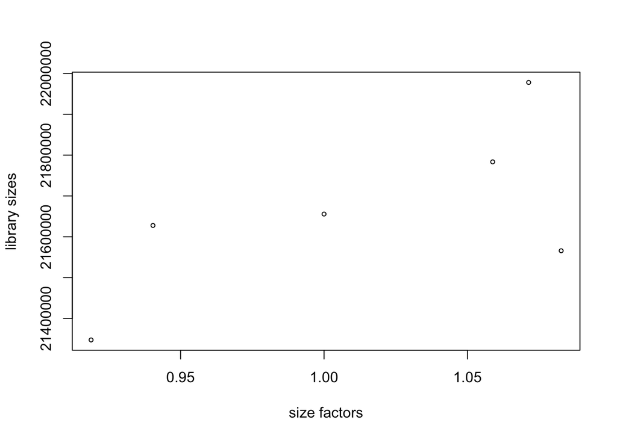

```r
#Size factor
DESeq.ds <- estimateSizeFactors(DESeq.ds)
plot( sizeFactors(DESeq.ds), colSums(counts(DESeq.ds)),
ylab = "library sizes", xlab = "size factors", cex = .6 )
```

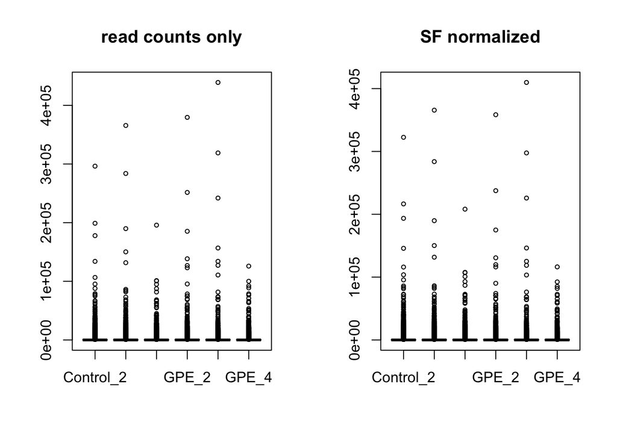

```r
par(mfrow=c(1,2))
## extracting normalized counts
counts.sf_normalized <- counts(DESeq.ds, normalized=TRUE)
boxplot(counts(DESeq.ds), main = "read counts only", cex = .6)
boxplot(counts.sf_normalized, main = "SF normalized", cex = .6)
```

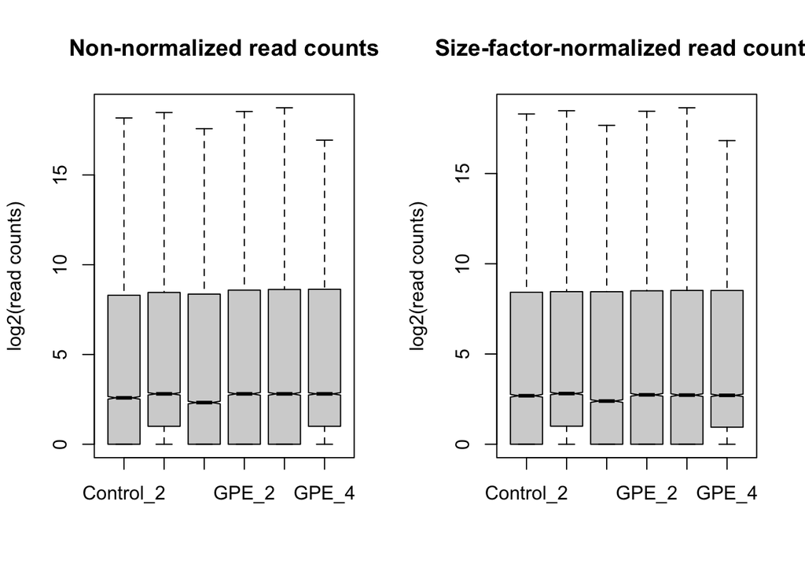

```r
par(mfrow=c(1,2))
boxplot(log2(counts(DESeq.ds) +1), notch=TRUE,
main = "Non-normalized read counts",
ylab ="log2(read counts)", cex = .6)
boxplot(log2(counts(DESeq.ds, normalized=TRUE) +1), notch=TRUE,
main = "Size-factor-normalized read counts",
ylab ="log2(read counts)", cex = .6)
```

```r
## non-normalized read counts plus pseudocount
log.counts <- log2(counts(DESeq.ds, normalized = FALSE) + 1)
assay(DESeq.ds, "log.counts") <- log2(counts(DESeq.ds, normalized = FALSE) + 1)
assay(DESeq.ds, "log.norm.counts") <- log2(counts(DESeq.ds, normalized=TRUE) + 1)
```

#### Within condition correlation plots

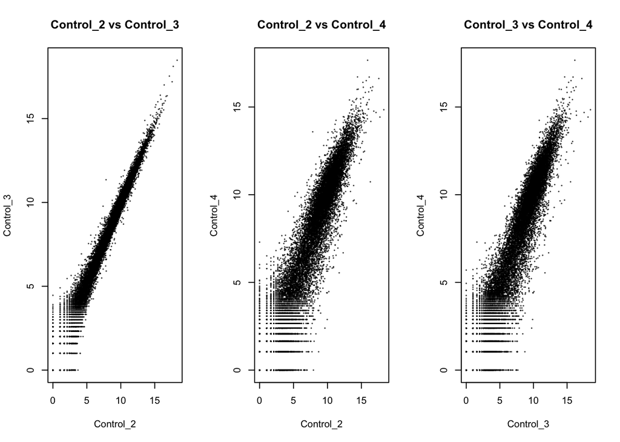

```r
par(mfrow=c(1,3))
DESeq.ds[, c("Control_2","Control_3")] %>%
assay(., "log.norm.counts") %>%
plot(., cex=.1, main = "Control_2 vs Control_3")
DESeq.ds[, c("Control_2","Control_4")] %>%
assay(., "log.norm.counts") %>%
plot(., cex=.1, main = "Control_2 vs Control_4")
DESeq.ds[, c("Control_3","Control_4")] %>%
assay(., "log.norm.counts") %>%
plot(., cex=.1, main = "Control_3 vs Control_4")
```

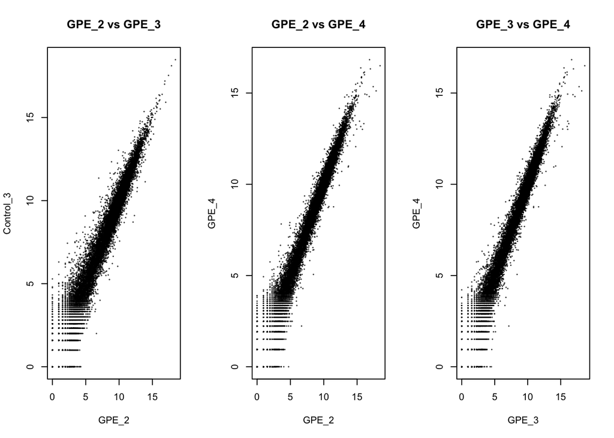

```r
par(mfrow=c(1,3))
DESeq.ds[, c("GPE_2","Control_3")] %>%
assay(., "log.norm.counts") %>%
plot(., cex=.1, main = "GPE_2 vs GPE_3")
DESeq.ds[, c("GPE_2","GPE_4")] %>%
assay(., "log.norm.counts") %>%
plot(., cex=.1, main = "GPE_2 vs GPE_4")
DESeq.ds[, c("GPE_3","GPE_4")] %>%
assay(., "log.norm.counts") %>%
plot(., cex=.1, main = "GPE_3 vs GPE_4")
```

#### Rlog transform

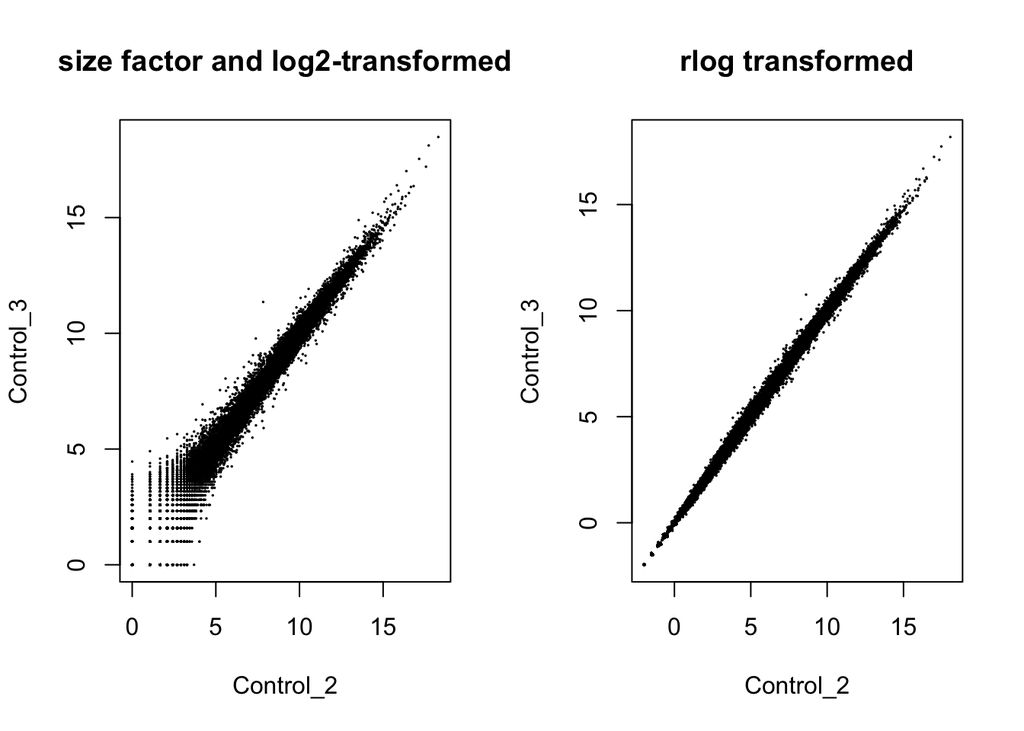

```r
DESeq.rlog <- rlog(DESeq.ds, blind = FALSE) #since being treated with drug, I am trying blind
par(mfrow=c(1,2))
plot(assay(DESeq.ds, "log.norm.counts")[,1:2], cex=.1,
main = "size factor and log2-transformed")
## the rlog-transformed counts are stored in the "assay" accessor
plot(assay(DESeq.rlog)[,1:2],
cex=.1, main = "rlog transformed",
xlab = colnames(assay(DESeq.rlog[,1])),
ylab = colnames(assay(DESeq.rlog[,2])) )
```

#### PCA Explorer

```r
#set to false for knitting purposes
library(pcaExplorer)
pcaExplorer(dds = DESeq.ds, dst = DESeq.rlog)
```

#### Save DESeq object

```r
save(DESeq.ds, DESeq.rlog, file = "NPC_DEseq.RData")
```

### Differential gene analaysis

Differential gene analysis was performed using DESeq() on the previously generated DEseq object with default parameters (Wald test). Multiple testing correction and independent filter was performed using results(DESeq.ds, independentFiltering = TRUE, alpha = 0.05). Histograms of the raw and adjusted pvalues were generated using hist(). Due to the unexpected pvalue distribution with Control 4 included, I ran the same differential gene analysis with Control 4 removed and regenerated raw and adjusted pvalue histograms. The distribution looked much more like what I would have expected for a drug treated experiment so I decided to use the results with Control 4 removed for further downstream analysis. Stacked histograms plots for raw and adjusted pvalues with and without control 4 were generated using ggplot2’s geom_histogram(). Heatmap of DEGs passing adjusted p value cutoff of 0.05 was generated using pheatmap(). DEGs used for input were rlog transformed and row-based z scored. Ensembl IDs were mapped to gene symbols using org.Hs.eg.db, in order to map ensembl IDs to their gene symbol if they have one, the versioning suffix (“.[0-9]”) was removed. Volcano plot was generated using EnhancedVolcano() with pCutoff=0.05 for adjusted pvalue and all other default parameters.

#### Load DEseq object

```r
library(DESeq2)
library(magrittr)

#load DEseq object
load("/Users/Caden/Desktop/angsd/project/angsd_project/DEseq/NPC_DEseq.RData")
DESeq.ds
```

```
## class: DESeqDataSet
## dim: 32213 6
## metadata(1): version
## assays(3): counts log.counts log.norm.counts
## rownames(32213): ENSG00000227232.5 ENSG00000268903.1 ...
##   ENSG00000210195.2 ENSG00000210196.2
## rowData names(0):
## colnames(6): Control_2 Control_3 ... GPE_3 GPE_4
## colData names(2): condition sizeFactor
```

#### Run DE analysis

```r
DESeq.ds %<>% DESeq()
```

#### Check raw p value distrubtion (with Control 4)

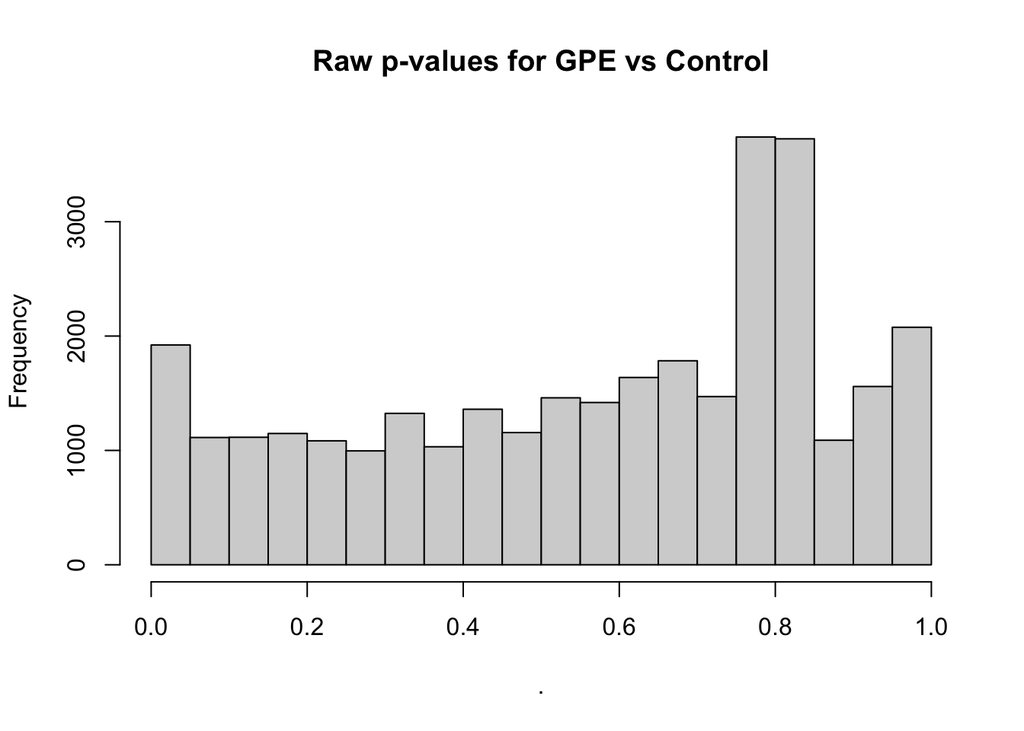

```r
rowData(DESeq.ds)$WaldPvalue_condition_GPE_vs_Control %>%
hist(breaks=19, main="Raw p-values for GPE vs Control")
```

```r
preOut_rawP <- rowData(DESeq.ds)$WaldPvalue_condition_GPE_vs_Control
```

#### Multiple testing correction and independent filtering

```r
DGE.results <- results(DESeq.ds, independentFiltering = TRUE, alpha = 0.05)
head(DGE.results)
```

```
## log2 fold change (MLE): condition GPE vs Control
## Wald test p-value: condition GPE vs Control
## DataFrame with 6 rows and 6 columns
##                     baseMean log2FoldChange     lfcSE      stat    pvalue
##                    <numeric>      <numeric> <numeric> <numeric> <numeric>
## ENSG00000227232.5   9.710261      -0.208983  0.690669 -0.302581  0.762209
## ENSG00000268903.1   0.855787      -2.062337  2.504959 -0.823301  0.410337
## ENSG00000241860.7   0.620866       2.685405  2.596876  1.034091  0.301094
## ENSG00000279457.4  19.428056       0.400898  0.695192  0.576672  0.564161
## ENSG00000228463.10  0.311354       1.688915  3.960410  0.426450  0.669780
## ENSG00000290385.1   0.311354       1.688915  3.960410  0.426450  0.669780
##                         padj
##                    <numeric>
## ENSG00000227232.5   0.948081
## ENSG00000268903.1         NA
## ENSG00000241860.7         NA
## ENSG00000279457.4   0.893186
## ENSG00000228463.10        NA
## ENSG00000290385.1         NA
```

```r
summary(DGE.results)
```

```
##
## out of 32213 with nonzero total read count
## adjusted p-value < 0.05
## LFC > 0 (up)       : 123, 0.38%
## LFC < 0 (down)     : 72, 0.22%
## outliers [1]       : 8, 0.025%
## low counts [2]     : 16862, 52%
## (mean count < 7)
## [1] see 'cooksCutoff' argument of ?results
## [2] see 'independentFiltering' argument of ?results
```

```r
table(DGE.results$padj < 0.05)
```

```
##
## FALSE  TRUE
## 15148   195
```

#### Check adjusted p value distrubtion (with Control 4)

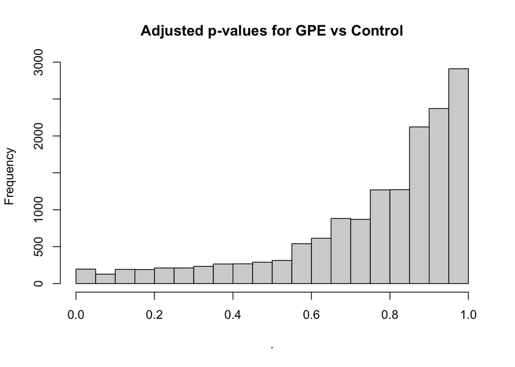

```r
DGE.results$padj %>%
hist(breaks=19, main="Adjusted p-values for GPE vs Control")
```

```r
preOut_adjP <- DGE.results$padj
```

#### Remove potential outlier and rerun DE Analysis

```r
DESeq.noOut.ds <- DESeq.ds[,-3]
DESeq.noOut.rlog <- DESeq.rlog[,-3]
DESeq.noOut.ds %<>% DESeq()
```

#### Check raw p value distrubtion (without Control 4)

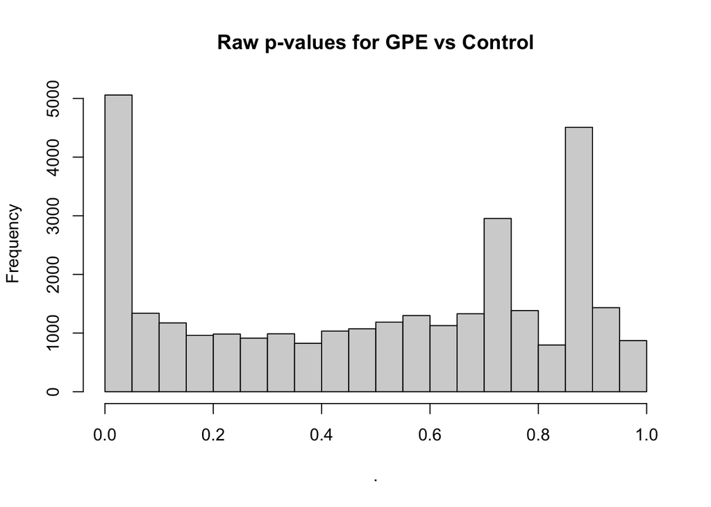

```r
rowData(DESeq.noOut.ds)$WaldPvalue_condition_GPE_vs_Control %>%
hist(breaks=19, main="Raw p-values for GPE vs Control")
```

```r
postOut_rawP <- rowData(DESeq.noOut.ds)$WaldPvalue_condition_GPE_vs_Control
```

#### Multiple testing correction and independent filtering (without Control 4)

```r
DGE.noOut.results <- results(DESeq.noOut.ds, independentFiltering = TRUE, alpha = 0.05)
head(DGE.noOut.results)
```

```
## log2 fold change (MLE): condition GPE vs Control
## Wald test p-value: condition GPE vs Control
## DataFrame with 6 rows and 6 columns
##                     baseMean log2FoldChange     lfcSE       stat    pvalue
##                    <numeric>      <numeric> <numeric>  <numeric> <numeric>
## ENSG00000227232.5   9.100115     -0.0384726  0.836618 -0.0459859  0.963321
## ENSG00000268903.1   0.388895     -0.6236966  4.086578 -0.1526207  0.878697
## ENSG00000241860.7   0.745040      2.6946321  2.886688  0.9334683  0.350578
## ENSG00000279457.4  22.675618     -0.0877863  0.516871 -0.1698418  0.865135
## ENSG00000228463.10  0.373625      1.6981009  4.113514  0.4128103  0.679746
## ENSG00000290385.1   0.373625      1.6981009  4.113514  0.4128103  0.679746
##                         padj
##                    <numeric>
## ENSG00000227232.5         NA
## ENSG00000268903.1         NA
## ENSG00000241860.7         NA
## ENSG00000279457.4   0.926427
## ENSG00000228463.10        NA
## ENSG00000290385.1         NA
```

```r
summary(DGE.noOut.results)
```

```
##
## out of 31232 with nonzero total read count
## adjusted p-value < 0.05
## LFC > 0 (up)       : 1524, 4.9%
## LFC < 0 (down)     : 1610, 5.2%
## outliers [1]       : 0, 0%
## low counts [2]     : 16926, 54%
## (mean count < 12)
## [1] see 'cooksCutoff' argument of ?results
## [2] see 'independentFiltering' argument of ?results
```

```r
table(DGE.noOut.results$padj < 0.05)
```

```
##
## FALSE  TRUE
## 11172  3134
```

#### Check adjusted p value distrubtion (without Control 4)

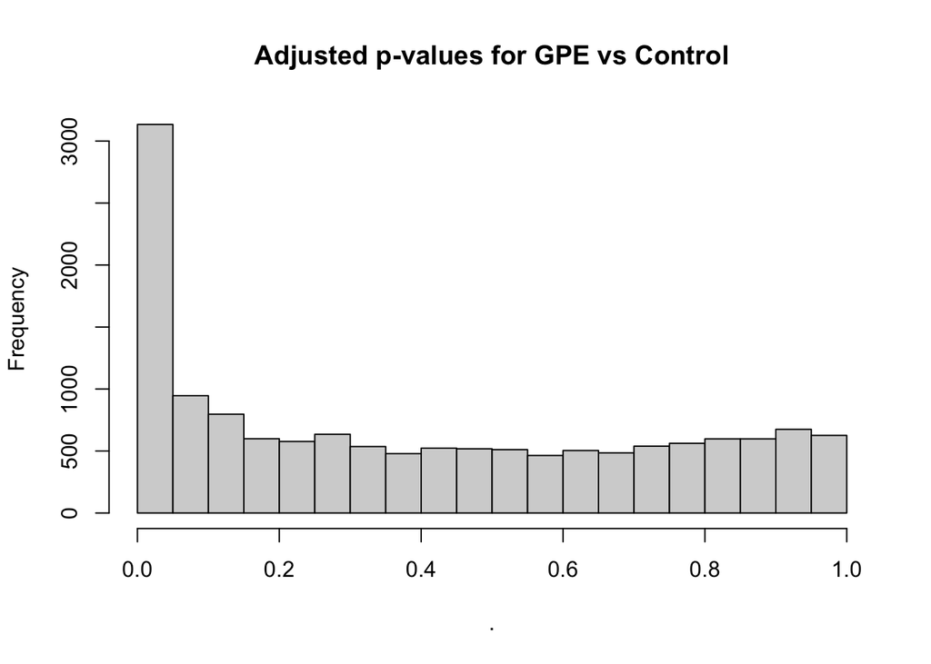

```r
DGE.noOut.results$padj %>%
hist(breaks=19, main="Adjusted p-values for GPE vs Control")
```

```r
postOut_adjP <- DGE.noOut.results$padj
```

#### ggplot of pvalue distrubtions +/- outlier

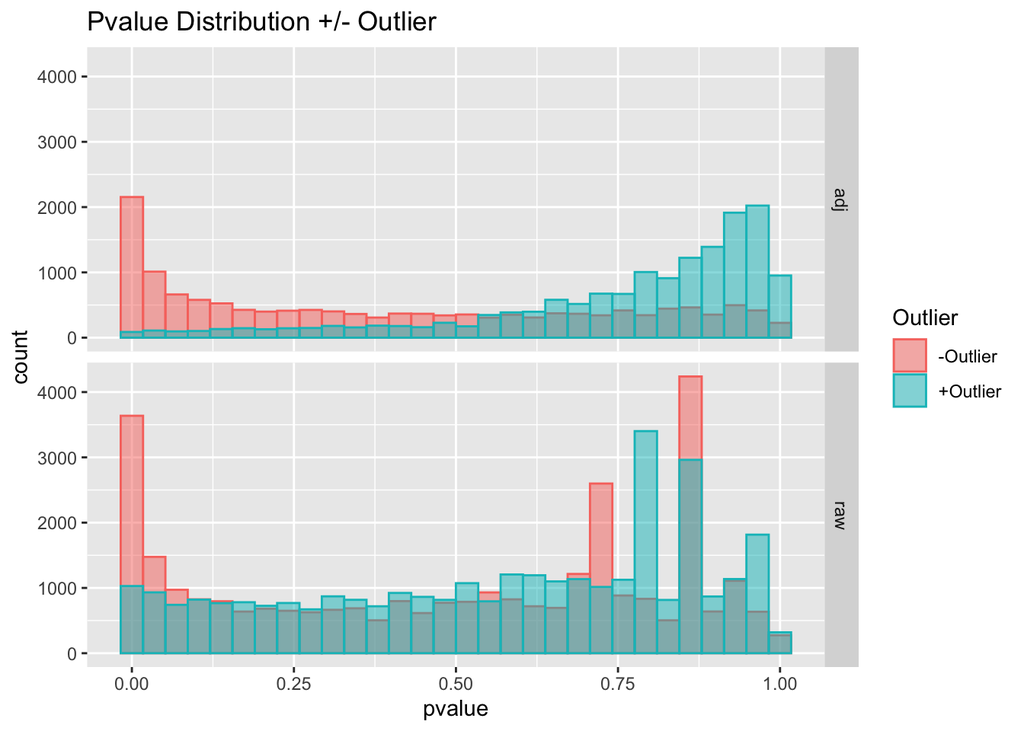

```r
library(ggplot2)
#gather data for ggplot df
pvalue <- c(preOut_rawP, preOut_adjP, postOut_rawP, postOut_adjP)
Outlier <- c(rep("+Outlier", length(preOut_rawP)), rep("+Outlier", length(preOut_adjP)), rep("-Outlier", length(postOut_rawP)), rep("-Outlier", length(postOut_adjP)) )
pval_type <- c(rep("raw", length(preOut_rawP)), rep("adj", length(preOut_adjP)), rep("raw", length(postOut_rawP)), rep("adj", length(postOut_adjP)) )
#Make ggplot df
hist_df <- data.frame(pvalue, Outlier, pval_type)

#plot stacked histogram
ggplot(hist_df, aes(x=pvalue, color=Outlier, fill = Outlier)) +
  geom_histogram(alpha=0.5, position="identity") +
  facet_grid(pval_type ~ .) + ggtitle("Pvalue Distribution +/- Outlier", )
```

#### Sort DEGs

```r
DGE.noOut.results.sorted <- DGE.noOut.results %>% `[`(order(.$padj),)
head(DGE.noOut.results.sorted)
```

```
## log2 fold change (MLE): condition GPE vs Control
## Wald test p-value: condition GPE vs Control
## DataFrame with 6 rows and 6 columns
##                     baseMean log2FoldChange     lfcSE      stat      pvalue
##                    <numeric>      <numeric> <numeric> <numeric>   <numeric>
## ENSG00000143382.16  1243.500       -2.76199  0.177836  -15.5311 2.13839e-54
## ENSG00000143369.15   667.557       -2.30785  0.175174  -13.1746 1.22807e-39
## ENSG00000128965.13   558.425        4.21158  0.330000   12.7624 2.65922e-37
## ENSG00000214049.8   1988.421       -3.03695  0.243593  -12.4673 1.12601e-35
## ENSG00000090539.16   588.628       -2.29242  0.203004  -11.2925 1.42925e-29
## ENSG00000163283.7   1514.746       -2.13726  0.200372  -10.6665 1.46046e-26
##                           padj
##                      <numeric>
## ENSG00000143382.16 3.05918e-50
## ENSG00000143369.15 8.78438e-36
## ENSG00000128965.13 1.26809e-33
## ENSG00000214049.8  4.02717e-32
## ENSG00000090539.16 4.08936e-26
## ENSG00000163283.7  3.48223e-23
```

#### Heatmap

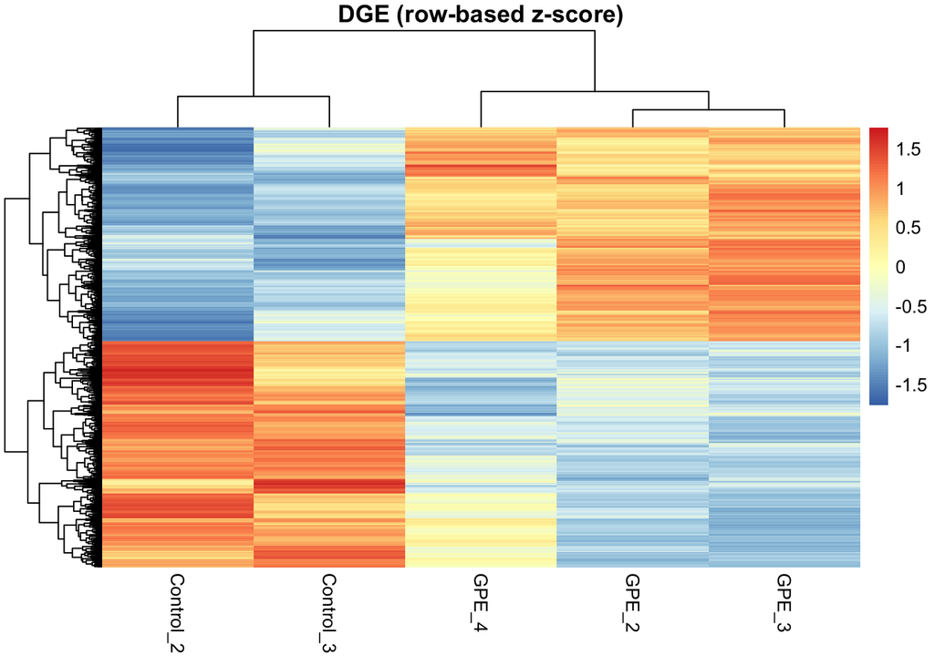

```r
library(pheatmap)
# identify genes with the desired adjusted p-value cut-off
DGE.noOut.genes <- rownames(subset(DGE.noOut.results.sorted, padj < 0.05))
rlog.noOut.dge <- DESeq.noOut.rlog [DGE.noOut.genes ,] %>% assay
pheatmap(rlog.noOut.dge , scale="row",
show_rownames=FALSE, main="DGE (row-based z-score)")
```

#### Add gene symbols

```r
#Trim ensembl ids
ensembl_noOut_ids <-rownames(DGE.noOut.results)
fixed_noOut_names <- sapply(strsplit(ensembl_noOut_ids, ".", fixed=T), function(x) x[1])
ensembl_noOut_ids_df <- data.frame(ensembl_noOut_ids, fixed_noOut_names)

library(org.Hs.eg.db)
human <- org.Hs.eg.db
## examine what keytypes are available to query the database
keytypes(human)
```

```
##  [1] "ACCNUM"       "ALIAS"        "ENSEMBL"      "ENSEMBLPROT"  "ENSEMBLTRANS"
##  [6] "ENTREZID"     "ENZYME"       "EVIDENCE"     "EVIDENCEALL"  "GENENAME"
## [11] "GENETYPE"     "GO"           "GOALL"        "IPI"          "MAP"
## [16] "OMIM"         "ONTOLOGY"     "ONTOLOGYALL"  "PATH"         "PFAM"
## [21] "PMID"         "PROSITE"      "REFSEQ"       "SYMBOL"       "UCSCKG"
## [26] "UNIPROT"
```

```r
annot.noOut.DGE <- select(human, keys=ensembl_noOut_ids_df$fixed_noOut_names,
keytype="ENSEMBL" , columns="SYMBOL")
colnames(annot.noOut.DGE) <- c("fixed_noOut_names", "SYMBOL")

ensembl_noOut_ids_df <- merge(x=ensembl_noOut_ids_df,y=annot.noOut.DGE,
        by="fixed_noOut_names", all.x=TRUE)
colnames(ensembl_noOut_ids_df)[2] <- "ensembl_ids"

DGE.noOut.results.sorted$ensembl_ids <- rownames(DGE.noOut.results.sorted)
DGE.noOut.results.sorted <- as.data.frame(DGE.noOut.results.sorted)
DGE.noOut.results.sorted <- merge(x = DGE.noOut.results.sorted, y = ensembl_noOut_ids_df, by= "ensembl_ids", all.x=TRUE)
DGE.noOut.results.sorted <- DGE.noOut.results.sorted[,-8]
```

#### Volcano Plot with gene symbols

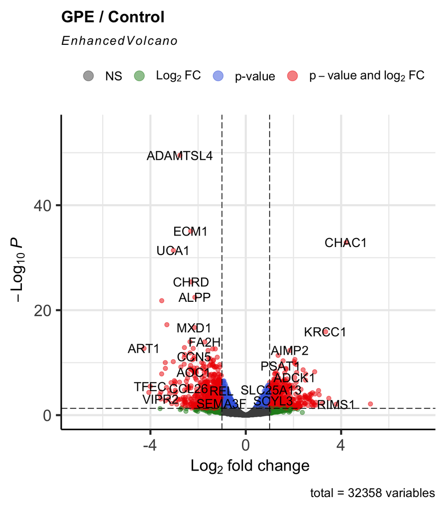

```r
library(EnhancedVolcano)
vp1 <- EnhancedVolcano(DGE.noOut.results.sorted,
lab= DGE.noOut.results.sorted$SYMBOL,
x='log2FoldChange', y='padj',
pCutoff=0.05,
title="GPE / Control")
print(vp1)
```

### Pathway enrichment

Pathway enrichment was performed using enrichR. Due to the limited number of DEGs passing both adjusted pvalue and log2 Fold Change thresholds, DEGs passing just an adjusted pvalue threshold of 0.05 separated into up and down regulated genes were used as input and KEGG_2021 database was used. Plots were generated using plotEnrich with showTerms = 15, numChar = 40, y = “Count”, orderBy = “Adjusted.P.value”.

#### EnrichR

```r
library(enrichR)
websiteLive <- getOption("enrichR.live")
if (websiteLive) {
    listEnrichrSites()
    setEnrichrSite("Enrichr") # Human genes
}
dbs <- listEnrichrDbs()

#subset into up/down regulated
sig_noOut_DEGs <- subset(DGE.noOut.results.sorted, padj < 0.05)
sig_noOut_upRegulated_DEGs <- subset(sig_noOut_DEGs, log2FoldChange > 0)
sig_noOut_downRegulated_DEGs <- subset(sig_noOut_DEGs, log2FoldChange < 0)
```

```r
#pathway enrichment on upreg
upReg_noOut_pathways <- enrichr(as.vector(na.omit(sig_noOut_upRegulated_DEGs$SYMBOL)), "KEGG_2021_Human")
```

```
## Uploading data to Enrichr... Done.
##   Querying KEGG_2021_Human... Done.
## Parsing results... Done.
```

```r
#pathway enrichment on downreg
downReg_noOut_pathways <- enrichr(as.vector(na.omit(sig_noOut_downRegulated_DEGs$SYMBOL)), "KEGG_2021_Human")
```

```
## Uploading data to Enrichr... Done.
##   Querying KEGG_2021_Human... Done.
## Parsing results... Done.
```

#### plot pathways

```r
library(cowplot)
upregulated_plot <- plotEnrich(upReg_noOut_pathways[[1]], showTerms = 15, numChar = 40, y = "Count", orderBy = "Adjusted.P.value", title = "Upregulated Pathways")
downregulated_plot <- plotEnrich(downReg_noOut_pathways[[1]], showTerms = 15, numChar = 40, y = "Count", orderBy = "Adjusted.P.value", , title = "Downregulated Pathways")
combined_plot <- plot_grid(upregulated_plot, downregulated_plot, labels = c('A', 'B'))
```

```r
ggsave(
  "Pathway_enrichment.png",
  combined_plot ,
  width = 12,
  height = 5,
  units = "in",
  dpi = 300
)
```

## Discussion

The first issue that I encountered was that my data was generated by BGISEQ and not Illumina. Furthermore the authors of the original paper only provided sparse descriptions of the library preparation and computational methods used in processing the RNA-seq. I did not know if my data was ribo-depleted or poly-A selected and they only provided a reference to DNA-seq protocol for BGISEQ. I had to do some extra reading on BGISEQ to learn if there were any major differences from Illumina that require different approaches. From what I can tell however, there isn’t that much of a difference from an analysis formatting perspective besides the oddity of the identical phred scores (which I’m still not sure what the cause is but I think its a dataset-specific thing and not a BGISEQ specific thing). I was also able to figure out some on the library preparation information from examining the reads in IGV.

The next issue that I had was the majority of my reads were mapping to “ambiguous” genes. I wasn’t sure if this was a artifact of parameters I had chosen, an issue with the library prep or sequencing before I even got the data, a GTF that had too many features, or if it was “real”. I went down a rabbit hole of trying to address it with featureCounts by using -O flag but after downloading a new GTF at Merv’s suggestion I discovered that it was just an issue with the GTF file I was using and not my data itself.

After getting a decent number of unique assigned reads from featureCounts for every sample, I then proceeded to exploratory analysis of the data in R. This is where I encountered my next issue which was the number of replicates per condition was on the low side and one of the control samples seemed to be an outlier. Consequently when I performed differential gene analysis, there was not as much of a transcriptional difference between conditions as I would have expected or compared to the results of the original study. Because this control sample seemed so much different that its other replicates I decided to remove it however this meant my results would be even more under powered.

Lastly, besides the lack of power in the data, it is also bulk RNA seq so we don’t know if the transcriptional effect we see in the drug treated group is similar across every cell or if its being driven by a subset of cells. This limitation is further amplified by the fact that the drug is being administered by a novel drug delivery system so and I don’t believe they had any readout for which cells successful got the drug when they did the RNA-seq experiment. Had this been single cell data, we would at least know the distribution of the effect across the drug treated cells. These two limitations of the data could be addressed by a follow up study with larger sample size and possibly scRNA-seq rather than bulk or at least some readout that can confirm the efficacy of the drug delivery in vitro.

### Dataset Table

| **Dataset** | **Used in final analysis** | **Location** | **URL** |
| --- | --- | --- | --- |
| Feature Counts matrix (-O flag, old GTF) | no | /angsd_project/FeatureCounts/old_counts/NPC_combined_featureCounts.txt | https://github.com/cadenmcquillen/angsd_project/blob/main/FeatureCounts/old_counts/NPC_combined_featureCounts.txt |
| Feature Counts matrix (old GTF) | no | /angsd_project/FeatureCounts/old_counts/reRun_NPC_combined_featureCounts.txt | https://github.com/cadenmcquillen/angsd_project/blob/main/FeatureCounts/old_counts/reRun_NPC_combined_featureCounts.txt |
| Feature Counts matrix (new GTF) | yes | /angsd_project/FeatureCounts/new_counts/newGTF_NPC_combined_featureCounts.txt | https://github.com/cadenmcquillen/angsd_project/blob/main/FeatureCounts/new_counts/newGTF_NPC_combined_featureCounts.txt |
| DEGs (with Control 4) | no | /angsd_project/DEGs/DEGs_with_control4.csv | https://github.com/cadenmcquillen/angsd_project/blob/main/DEGs/DEGs_with_control4.csv |
| DEGs (without Control 4) | yes | /angsd_project/DEGs/DEGs_no_control4.csv | https://github.com/cadenmcquillen/angsd_project/blob/main/DEGs/DEGs_no_control4.csv |
| DEGs (Upregulated without control 4) | yes | /angsd_project/DEGs/Upregulated_DEGs_no_control4.csv | https://github.com/cadenmcquillen/angsd_project/blob/main/DEGs/Upregulated_DEGs_no_control4.csv |
| DEGs (Downregulated without control 4) | yes | /angsd_project/DEGs/Downregulated_DEGs_no_control4.csv | https://github.com/cadenmcquillen/angsd_project/blob/main/DEGs/Downregulated_DEGs_no_control4.csv |
| KEGG pathway enrichment (Upregulated) | yes | /angsd_project/Pathway_Enrichment/Upregulated_KEGG_pathways.csv | https://github.com/cadenmcquillen/angsd_project/blob/main/Pathway_Enrichment/Upregulated_KEGG_pathways.csv |
| KEGG pathway enrichment (Downregulated) | yes | /angsd_project/Pathway_Enrichment/Downregulated_KEGG_pathways.csv | https://github.com/cadenmcquillen/angsd_project/blob/main/Pathway_Enrichment/Downregulated_KEGG_pathways.csv |

## Citations

1. Lan MY, Hsu YB, Lan MC, Chen JP, Lu YJ. Polyethylene Glycol-Coated Graphene Oxide Loaded with Erlotinib as an Effective Therapeutic Agent for Treating Nasopharyngeal Cancer Cells. Int J Nanomedicine. 2020 Oct 7;15:7569-7582.
2. Li D, Zhang W, Yu X, Wang Z, Su Z, Wei G. When biomolecules meet graphene: from molecular level interactions to material design and applications. Nanoscale. 2016 Dec 1;8(47):19491-19509. doi: 10.1039/c6nr07249f.
3. Oda K, Matsuoka Y, Funahashi A, Kitano H. A comprehensive pathway map of epidermal growth factor receptor signaling. Mol Syst Biol. 2005;1:2005.0010.
4. Wang, X., Xuan, Z., Zhu, X. et al. Near-infrared photoresponsive drug delivery nanosystems for cancer photo-chemotherapy. J Nanobiotechnol 18, 108 (2020).
5. Wong, K.C.W., Hui, E.P., Lo, KW. et al. Nasopharyngeal carcinoma: an evolving paradigm. Nat Rev Clin Oncol 18, 679–695 (2021).